# Data 607 Project 1

Nikoleta Emanouilidi

2024-02-14

```r
library(dplyr)
```

```r
library(readr)
library(tidyr)
library(stringr)
library(ggplot2)
```

### We start by reading the raw data file after I uploaded it in Github.

```r
Raw_data <-readLines("https://raw.githubusercontent.com/NikoletaEm/607LABS/main/tournamentinfo.txt" )
head(Raw_data)
```

```
## [1] "-----------------------------------------------------------------------------------------"
## [2] " Pair | Player Name                     |Total|Round|Round|Round|Round|Round|Round|Round| "
## [3] " Num  | USCF ID / Rtg (Pre->Post)       | Pts |  1  |  2  |  3  |  4  |  5  |  6  |  7  | "
## [4] "-----------------------------------------------------------------------------------------"
## [5] "    1 | GARY HUA                        |6.0  |W  39|W  21|W  18|W  14|W   7|D  12|D   4|"
## [6] "   ON | 15445895 / R: 1794   ->1817     |N:2  |W    |B    |W    |B    |W    |B    |W    |"
```

```r
tail(Raw_data)
```

```
## [1] "   63 | THOMAS JOSEPH HOSMER            |1.0  |L   2|L  48|D  49|L  43|L  45|H    |U    |"
## [2] "   MI | 15057092 / R: 1175   ->1125     |     |W    |B    |W    |B    |B    |     |     |"
## [3] "-----------------------------------------------------------------------------------------"
## [4] "   64 | BEN LI                          |1.0  |L  22|D  30|L  31|D  49|L  46|L  42|L  54|"
## [5] "   MI | 15006561 / R: 1163   ->1112     |     |B    |W    |W    |B    |W    |B    |B    |"
## [6] "-----------------------------------------------------------------------------------------"
```

### Our data in the format it is, is actually very difficult to read and interpret. We need to make some ajustments to it.First of all,the ‘|’ character is used as a delimiter or separator in our data to mark the boundaries between the different columns.By finding the positions of ‘|’ characters in the fifth column, the code is likely trying to understand the structure of the data and extract relevant information from it.

```r
P0 = 0
P1 = unname(str_locate_all(pattern = '\\|', Raw_data[5])[[1]][1,1])#we found the position of the first '|' character in the fifth column of Raw_data and stored that position in the variable x1
P2 = unname(str_locate_all(pattern = '\\|', Raw_data[5])[[1]][2,1]) ## Similar to the previous line, but we found the position of the second '|' character in the fifth column and stored that position in the variable x2
P3 = unname(str_locate_all(pattern = '\\|', Raw_data[5])[[1]][3,1])
```

### Our aim now is to keep only the important data like names,numbers, state etc and get rid of the dotted lines.

```r
group_1 = Raw_data[seq(5, 196,3)]
group_2 = Raw_data[seq(6, 196, 3)]
head(group_1)
```

```
## [1] "    1 | GARY HUA                        |6.0  |W  39|W  21|W  18|W  14|W   7|D  12|D   4|"
## [2] "    2 | DAKSHESH DARURI                 |6.0  |W  63|W  58|L   4|W  17|W  16|W  20|W   7|"
## [3] "    3 | ADITYA BAJAJ                    |6.0  |L   8|W  61|W  25|W  21|W  11|W  13|W  12|"
## [4] "    4 | PATRICK H SCHILLING             |5.5  |W  23|D  28|W   2|W  26|D   5|W  19|D   1|"
## [5] "    5 | HANSHI ZUO                      |5.5  |W  45|W  37|D  12|D  13|D   4|W  14|W  17|"
## [6] "    6 | HANSEN SONG                     |5.0  |W  34|D  29|L  11|W  35|D  10|W  27|W  21|"
```

```r
head(group_2)
```

```
## [1] "   ON | 15445895 / R: 1794   ->1817     |N:2  |W    |B    |W    |B    |W    |B    |W    |"
## [2] "   MI | 14598900 / R: 1553   ->1663     |N:2  |B    |W    |B    |W    |B    |W    |B    |"
## [3] "   MI | 14959604 / R: 1384   ->1640     |N:2  |W    |B    |W    |B    |W    |B    |W    |"
## [4] "   MI | 12616049 / R: 1716   ->1744     |N:2  |W    |B    |W    |B    |W    |B    |B    |"
## [5] "   MI | 14601533 / R: 1655   ->1690     |N:2  |B    |W    |B    |W    |B    |W    |B    |"
## [6] "   OH | 15055204 / R: 1686   ->1687     |N:3  |W    |B    |W    |B    |B    |W    |B    |"
```

### We succesfully managed (after many failed attempts) to remove all the dotted/underscored lines from our data frame and also grouped our data in 2 groups.We did that beacause If we try to put them in 1 group it makes it very difficult to us to categorize and summarize our data.

## Let’s tidy up the names of the players first.We want both the “|” and the spaces/tabs removed.

```r
name = substr(group_1, P1+1, P2-2) ## if we wrote (group1, P1, P2) we would include the "|" both before the names and also after
Players_names = gsub("^\\s+|\\s+$", "", name)
head(Players_names)
```

```
## [1] "GARY HUA"            "DAKSHESH DARURI"     "ADITYA BAJAJ"
## [4] "PATRICK H SCHILLING" "HANSHI ZUO"          "HANSEN SONG"
```

### Let’s tidy up the states using the same technique.This process is a bit timeconsuming but I couldn’t figure out anything else.

```r
state = substr(group_2, P0, P1-1) ## Again if we wrote (group2, P0, P1) or (group2, P0, P1+1) it'd keep the "|" at the end of each state. We didn't guess the P1-1 we try different things and see which gives the desired result.
States = gsub("^\\s+|\\s+$", "", state)
head(States)
```

```
## [1] "ON" "MI" "MI" "MI" "MI" "OH"
```

### Next is the Total_Pts

```r
total_points = substr(group_1, P2 + 1, P3 - 1) ## Same thing as above we need to get rid off "|"
Total_Pts = gsub("^\\s+|\\s+$", "", total_points)
head(Total_Pts)
```

```
## [1] "6.0" "6.0" "6.0" "5.5" "5.5" "5.0"
```

### Now we move on to Group 2 to tidy up some of the data there as well

### Let’s start by tidying up the players pre-rating.

```r
Pre_Rate = substr(group_2, P1 + 1, P2 - 1)
Players_PreRate =gsub(".*:(\\s*\\d{2,}).*", "\\1", Pre_Rate) ## Removed all the /,R,:,->.Basically kept only the numbers.
head(Players_PreRate)
```

```
## [1] " 1794" " 1553" " 1384" " 1716" " 1655" " 1686"
```

### Now that the data is tidied up,cleaned and easy to read, we need to place it in a new data frame.

```r
Project1 = data.frame(Players_names, States,Total_Pts,Players_PreRate)
View(Project1)
```

### Now lets make a function that calculates the Average Pre Chess Rating of Opponents

```r
size= max(nchar(Raw_data)) ##By finding the maximum number of characters in any cell, the code can determine the width of the table or the maximum length of content in the Raw_Data.We are doing that in order to ensure that all data is displayed properly.
Opponents = substr(group_1, P3 + 1, size) ## We will opponent information from the group1
opp = str_extract_all(Opponents, '\\b\\d{1,}') ## We will extract all numeric values from the Opponents variable, which contains opponent IDs for each player.
opp = as.matrix(opp) ## We will extract opponent IDs into a matrix format, which will need for later.

avgoppprerate <- function(y, z) {
  x <- y[z]
  rates <- numeric(length(x))

  for (i in seq_along(x)) {
    rate <- 0
    c <- 0
    for (b in x[[i]]) {
      if (!is.na(b)) {
        c <- c + 1
        rate <- rate + as.numeric(Project1$Players_PreRate[as.numeric(b)]) ## the class of Players_PreRate is char so I had to change it to numeric
      } else {
        cat("Encountered NA in opponent ID for player", i, "\n")
      }
    }
    if (c > 0) {
      rates[i] <- round(rate / c)
    } else {
      cat("No valid opponent IDs found for player", i, "\n")
      rates[i] <- NA
    }
  }

  return(rates)
}

Project1$AvgOppPreRating = apply(opp, 1, avgoppprerate)
View(Project1)
```

### And here’s a plot showing the total points of the players grouped by the States

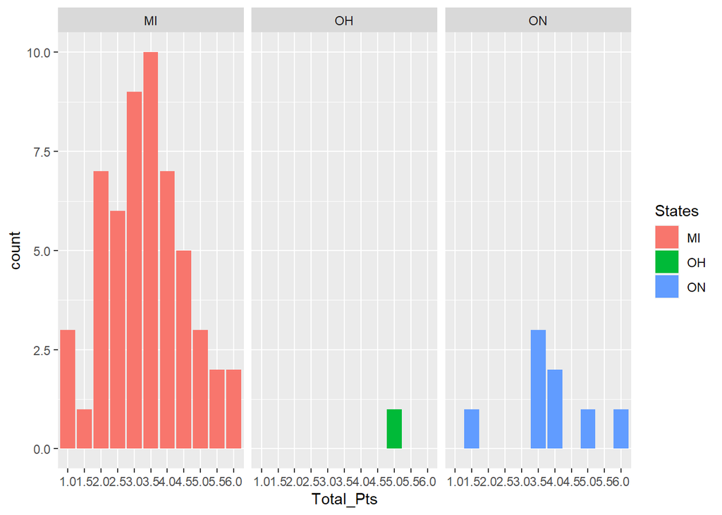

```r
ggplot(Project1,aes(x=Total_Pts,fill=States))+geom_bar()+facet_wrap(~States)
```

```r
write.csv(Project1,"chess_tournamentinfo.csv")
```

### Let’s read the csv version we created! (just to be 100% sure everything is ok)

```r
test<-read.csv("https://raw.githubusercontent.com/NikoletaEm/607LABS/main/chess_tournamentinfo.csv")
View(test)
```